# Mendelian Randomization Analysis

Dr. Shea Andrews

2020-12-18

## Instrumental Variables

**SNP Inclusion:** SNPS associated with at a p-value threshold of p < 5e-8 were included in this analysis.

**LD Clumping:** For standard two sample MR it is important to ensure that the instruments for the exposure are independent. LD clumping was performed in PLINK using the EUR samples from the 1000 Genomes Project to estimate LD between SNPs, and, amongst SNPs that have an LD above a given threshold, retain only the SNP with the lowest p-value. A clumping window of 10^{4}, r2 of 0.001 and significance level of 1 was used for the index and secondary SNPs.

**Proxy SNPs:** Where SNPs were not available in the outcome GWAS, the EUR thousand genomes was queried to identify potential proxy SNPs that are in linkage disequilibrium (r2 > 0.8) of the missing SNP.

### Exposure: WBC

**Table 1:** Independent SNPs associated with WBC

| SNP | CHROM | POS | REF | ALT | AF | BETA | SE | Z | P | N | TRAIT |
| --- | --- | --- | --- | --- | --- | --- | --- | --- | --- | --- | --- |
| rs112613745 | 1 | 8634427 | G | A | 0.1880 | 0.02779682 | 0.004585995 | 6.061241 | 1.351e-09 | 173480 | WBC |
| rs6684709 | 1 | 23850023 | G | C | 0.6200 | -0.02243384 | 0.003680635 | -6.095100 | 1.094e-09 | 173480 | WBC |
| rs12142239 | 1 | 28188261 | G | A | 0.1041 | -0.03532819 | 0.005853422 | -6.035476 | 1.585e-09 | 173480 | WBC |
| rs3917932 | 1 | 36943916 | C | G | 0.5759 | -0.04220662 | 0.003631785 | -11.621453 | 3.206e-31 | 173480 | WBC |
| rs7520047 | 1 | 46432101 | A | C | 0.4175 | -0.02403073 | 0.003708004 | -6.480772 | 9.125e-11 | 173480 | WBC |
| rs34293785 | 1 | 66137192 | T | C | 0.3663 | -0.04583130 | 0.003735474 | -12.269206 | 1.325e-34 | 173480 | WBC |
| rs41313381 | 1 | 79411968 | C | A | 0.0307 | 0.05808968 | 0.010369380 | 5.602040 | 2.118e-08 | 173480 | WBC |
| rs3176867 | 1 | 101194205 | C | T | 0.2448 | -0.02377228 | 0.004295870 | -5.533752 | 3.135e-08 | 173480 | WBC |
| rs2476601 | 1 | 114377568 | A | G | 0.8983 | 0.05610971 | 0.005907726 | 9.497683 | 2.146e-21 | 173480 | WBC |
| rs34599082 | 1 | 159175494 | C | T | 0.0138 | -0.15272980 | 0.015376710 | -9.932541 | 3.005e-23 | 173480 | WBC |

[output cut: 166 more lines]

### Outcome: COVID: B2

**Table 2:** SNPs associated with WBC avaliable in COVID: B2

| SNP | CHROM | POS | REF | ALT | AF | BETA | SE | Z | P | N | TRAIT |
| --- | --- | --- | --- | --- | --- | --- | --- | --- | --- | --- | --- |
| rs112613745 | 1 | 8634427 | G | A | 0.187400 | -8.4451e-02 | 0.032266 | -2.6173371351 | 8.862e-03 | 1338138 | COVID:_hospitalized_vs._population__eur |
| rs6684709 | 1 | 23850023 | G | C | 0.631300 | -6.5920e-02 | 0.022397 | -2.9432513283 | 3.248e-03 | 1589523 | COVID:_hospitalized_vs._population__eur |
| rs12142239 | 1 | 28188261 | G | A | 0.108500 | -4.9849e-02 | 0.034508 | -1.4445635795 | 1.486e-01 | 1589523 | COVID:_hospitalized_vs._population__eur |
| rs3917932 | 1 | 36943916 | C | G | 0.574500 | -7.7266e-03 | 0.028564 | -0.2705013303 | 7.868e-01 | 898438 | COVID:_hospitalized_vs._population__eur |
| rs41313381 | 1 | 79411968 | C | A | 0.032690 | -2.8460e-02 | 0.063539 | -0.4479138797 | 6.542e-01 | 1589523 | COVID:_hospitalized_vs._population__eur |
| rs3176867 | 1 | 101194205 | C | T | 0.254500 | -3.6847e-03 | 0.034948 | -0.1054337873 | 9.160e-01 | 1576851 | COVID:_hospitalized_vs._population__eur |
| rs2476601 | 1 | 114377568 | A | G | 0.885900 | 1.0376e-02 | 0.039370 | 0.2635509271 | 7.921e-01 | 1589523 | COVID:_hospitalized_vs._population__eur |
| rs34599082 | 1 | 159175494 | C | T | 0.013900 | -5.2580e-02 | 0.084355 | -0.6233181199 | 5.331e-01 | 1588910 | COVID:_hospitalized_vs._population__eur |
| rs377720202 | 1 | 161620432 | C | T | 0.144300 | 9.6628e-02 | 0.055180 | 1.7511417180 | 7.992e-02 | 882978 | COVID:_hospitalized_vs._population__eur |
| rs34889541 | 1 | 198594769 | G | A | 0.075970 | 6.0526e-02 | 0.040653 | 1.4888446117 | 1.365e-01 | 1589523 | COVID:_hospitalized_vs._population__eur |

[output cut: 166 more lines]

**Table 3:** Proxy SNPs for COVID: B2

| target_snp | proxy_snp | ld.r2 | Dprime | PHASE | X12 | CHROM | POS | REF.proxy | ALT.proxy | AF | BETA | SE | Z | P | N | TRAIT | ref | ref.proxy | alt | alt.proxy | ALT | REF | proxy.outcome |
| --- | --- | --- | --- | --- | --- | --- | --- | --- | --- | --- | --- | --- | --- | --- | --- | --- | --- | --- | --- | --- | --- | --- | --- |
| rs7520047 | rs7520050 | 0.983649 | 0.995867 | CC/AA | NA | 1 | 46432105 | A | C | 0.4152 | -0.025917 | 0.029142 | -0.8893350 | 0.3738000 | 1061111 | COVID:_hospitalized_vs._population__eur | C | C | A | A | C | A | TRUE |
| rs34293785 | rs1938498 | 0.974919 | 1.000000 | CC/TT | NA | 1 | 66098653 | T | C | 0.3916 | 0.032862 | 0.021944 | 1.4975392 | 0.1342000 | 1589523 | COVID:_hospitalized_vs._population__eur | C | C | T | T | C | T | TRUE |
| rs9270636 | rs9270772 | 0.815539 | 0.988874 | CC/AT | NA | 6 | 32568967 | T | C | 0.2838 | -0.029778 | 0.033447 | -0.8903041 | 0.3733000 | 892591 | COVID:_hospitalized_vs._population__eur | C | C | A | T | C | A | TRUE |
| rs71548708 | rs6454593 | 0.917429 | 0.971292 | TA/CG | NA | 6 | 87904899 | G | A | 0.4834 | -0.070929 | 0.021456 | -3.3057886 | 0.0009471 | 1589523 | COVID:_hospitalized_vs._population__eur | T | A | C | G | T | C | TRUE |
| rs28521954 | rs14408 | 0.887553 | 0.944094 | GC/TT | NA | 11 | 308314 | T | C | 0.3650 | -0.025652 | 0.027331 | -0.9385679 | 0.3480000 | 1576236 | COVID:_hospitalized_vs._population__eur | G | C | T | T | G | T | TRUE |
| rs60606273 | rs3848148 | 0.884128 | 0.959198 | AT/TC | NA | 15 | 64637536 | T | C | 0.9374 | -0.012766 | 0.050796 | -0.2513190 | 0.8016000 | 1579467 | COVID:_hospitalized_vs._population__eur | A | T | T | C | T | A | TRUE |
| rs9330533 | rs9330536 | 0.980101 | 0.991978 | TC/CT | NA | 17 | 81083854 | T | C | 0.4746 | -0.021276 | 0.039108 | -0.5440319 | 0.5864000 | 884795 | COVID:_hospitalized_vs._population__eur | T | C | C | T | T | C | TRUE |
| rs10206089 | NA | NA | NA | NA | NA | NA | NA | NA | NA | NA | NA | NA | NA | NA | NA | NA | NA | NA | NA | NA | NA | NA | NA |
| rs1611434 | NA | NA | NA | NA | NA | NA | NA | NA | NA | NA | NA | NA | NA | NA | NA | NA | NA | NA | NA | NA | NA | NA | NA |
| rs9273608 | NA | NA | NA | NA | NA | NA | NA | NA | NA | NA | NA | NA | NA | NA | NA | NA | NA | NA | NA | NA | NA | NA | NA |

[output cut: 2 more lines]

## Data harmonization

Harmonize the exposure and outcome datasets so that the effect of a SNP on the exposure and the effect of that SNP on the outcome correspond to the same allele. The harmonise_data function from the TwoSampleMR package can be used to perform the harmonization step, by default it try’s to infer the forward strand alleles using allele frequency information.

**Table 4:** Harmonized WBC and COVID: B2 datasets

| SNP | effect_allele.exposure | other_allele.exposure | effect_allele.outcome | other_allele.outcome | beta.exposure | beta.outcome | eaf.exposure | eaf.outcome | remove | palindromic | ambiguous | id.outcome | chr.outcome | pos.outcome | se.outcome | z.outcome | pval.outcome | samplesize.outcome | outcome | mr_keep.outcome | pval_origin.outcome | chr.exposure | pos.exposure | se.exposure | z.exposure | pval.exposure | samplesize.exposure | exposure | mr_keep.exposure | … |
| --- | --- | --- | --- | --- | --- | --- | --- | --- | --- | --- | --- | --- | --- | --- | --- | --- | --- | --- | --- | --- | --- | --- | --- | --- | --- | --- | --- | --- | --- | --- |
| rs10075801 | G | A | G | A | -0.03816809 | -1.4645e-03 | 0.4856 | 0.481600 | FALSE | FALSE | FALSE | fQWt53 | 5 | 131677642 | 0.026609 | -0.0550377692 | 9.561e-01 | 1063727 | covidhgi2020anaB2v4eur23andMe | TRUE | reported | 5 | 131677642 | 0.003625878 | -10.526579 | 6.516e-26 | 173480 | Astel2016wbc | TRUE | … |
| rs10087240 | T | C | T | C | 0.02401676 | 2.4840e-03 | 0.4564 | 0.467400 | FALSE | FALSE | FALSE | fQWt53 | 8 | 129012574 | 0.024842 | 0.0999919491 | 9.204e-01 | 1579467 | covidhgi2020anaB2v4eur23andMe | TRUE | reported | 8 | 129012574 | 0.003637955 | 6.601720 | 4.064e-11 | 173480 | Astel2016wbc | TRUE | … |
| rs10104003 | T | C | T | C | -0.02461796 | 6.5491e-02 | 0.2027 | 0.210700 | FALSE | FALSE | FALSE | fQWt53 | 8 | 55422440 | 0.027021 | 2.4237074868 | 1.536e-02 | 1589523 | covidhgi2020anaB2v4eur23andMe | TRUE | reported | 8 | 55422440 | 0.004472406 | -5.504411 | 3.704e-08 | 173480 | Astel2016wbc | TRUE | … |
| rs10138752 | T | C | T | C | -0.04641403 | -4.0379e-02 | 0.0776 | 0.081160 | FALSE | FALSE | FALSE | fQWt53 | 14 | 69179971 | 0.042267 | -0.9553315826 | 3.394e-01 | 1589523 | covidhgi2020anaB2v4eur23andMe | TRUE | reported | 14 | 69179971 | 0.006722711 | -6.904064 | 5.054e-12 | 173480 | Astel2016wbc | TRUE | … |
| rs10178094 | A | C | A | C | -0.02114093 | 1.0470e-02 | 0.4675 | 0.455700 | FALSE | FALSE | FALSE | fQWt53 | 2 | 161336406 | 0.024697 | 0.4239381301 | 6.716e-01 | 1579467 | covidhgi2020anaB2v4eur23andMe | TRUE | reported | 2 | 161336406 | 0.003591294 | -5.886717 | 3.939e-09 | 173480 | Astel2016wbc | TRUE | … |
| rs1025687 | C | T | C | T | -0.02076005 | 2.3302e-02 | 0.6253 | 0.631700 | FALSE | FALSE | FALSE | fQWt53 | 18 | 48147793 | 0.025636 | 0.9089561554 | 3.634e-01 | 1579467 | covidhgi2020anaB2v4eur23andMe | TRUE | reported | 18 | 48147793 | 0.003738094 | -5.553646 | 2.798e-08 | 173480 | Astel2016wbc | TRUE | … |
| rs10466905 | A | G | A | G | 0.03991740 | -3.9441e-02 | 0.1918 | 0.188400 | FALSE | FALSE | FALSE | fQWt53 | 12 | 6502832 | 0.032650 | -1.2079938744 | 2.270e-01 | 1579467 | covidhgi2020anaB2v4eur23andMe | TRUE | reported | 12 | 6502832 | 0.004581131 | 8.713438 | 2.948e-18 | 173480 | Astel2016wbc | TRUE | … |
| rs1047891 | A | C | A | C | -0.02146777 | 7.0951e-03 | 0.3168 | 0.308800 | FALSE | FALSE | FALSE | fQWt53 | 2 | 211540507 | 0.022847 | 0.3105484309 | 7.561e-01 | 1589523 | covidhgi2020anaB2v4eur23andMe | TRUE | reported | 2 | 211540507 | 0.003839559 | -5.591207 | 2.255e-08 | 173480 | Astel2016wbc | TRUE | … |
| rs10786156 | G | C | G | C | -0.02011275 | -4.9286e-02 | 0.4342 | 0.431500 | FALSE | TRUE | TRUE | fQWt53 | 10 | 96014622 | 0.021554 | -2.2866289320 | 2.222e-02 | 1589523 | covidhgi2020anaB2v4eur23andMe | TRUE | reported | 10 | 96014622 | 0.003619133 | -5.557339 | 2.739e-08 | 173480 | Astel2016wbc | TRUE | … |
| rs10786327 | T | C | T | C | 0.05000236 | -1.1913e-02 | 0.5961 | 0.588200 | FALSE | FALSE | FALSE | fQWt53 | 10 | 99071408 | 0.021947 | -0.5428076730 | 5.873e-01 | 1589523 | covidhgi2020anaB2v4eur23andMe | TRUE | reported | 10 | 99071408 | 0.003665646 | 13.640804 | 2.290e-42 | 173480 | Astel2016wbc | TRUE | … |

[output cut: 161 more lines]

SNPs that genome-wide significant in the outcome GWAS are likely pleitorpic and should be removed from analysis. Additionaly remove variants within the APOE locus by exclude variants 1MB either side of APOE e4 (rs429358 = 19:45411941, GRCh37.p13)

**Table 5:** SNPs that were genome-wide significant in the COVID: B2 GWAS

| SNP | chr.outcome | pos.outcome | pval.exposure | pval.outcome |
| --- | --- | --- | --- | --- |

## Instrument Strength

To ensure that the first assumption of MR is not violated (Non-zero effect assumption), the genetic variants selected should be robustly associated with the exposure. Weak instruments, where the variance in the exposure explained by the the instruments is a small portion of the total variance, may result in poor precission and accuracy of the causal effect estiamte. The strength of an instrument can be evaluated using the F statistic, if F is less than 10, this is an indication of weak instrument.

| outliers_removed | pve.exposure | F | Alpha | NCP | Power |
| --- | --- | --- | --- | --- | --- |
| FALSE | 0.06909984 | 78.44517 | 0.05 | 15.71381 | 0.9774703 |
| TRUE | 0.06859651 | 78.30964 | 0.05 | 12.30153 | 0.9391153 |

The I2_GX statistic can be used to quantify the strength of the NOME violation for MR-Egger regression and should be used to evalute potential bias in the MR-Egger causal estimate, with values less then 90% indicating that causal estimated should interpreted with caution due to regression diluation.

| outliers_removed | Isq_gx |
| --- | --- |
| FALSE | 0.9158548 |
| TRUE | NA |

## MR Results

To obtain an overall estimate of causal effect, the SNP-exposure and SNP-outcome coefficients were combined in 1) a fixed-effects meta-analysis using an inverse-variance weighted approach (IVW); 2) a Weighted Median approach; 3) Weighted Mode approach and 4) Egger Regression.

[**IVW**](https://doi.org/10.1002/gepi.21758) is equivalent to a weighted regression of the SNP-outcome coefficients on the SNP-exposure coefficients with the intercept constrained to zero. This method assumes that all variants are valid instrumental variables based on the Mendelian randomization assumptions. The causal estimate of the IVW analysis expresses the causal increase in the outcome (or log odds of the outcome for a binary outcome) per unit change in the exposure. [**Weighted median MR**](https://doi.org/10.1002/gepi.21965) allows for 50% of the instrumental variables to be invalid. [**MR-Egger regression**](https://doi.org/10.1093/ije/dyw220) allows all the instrumental variables to be subject to direct effects (i.e. horizontal pleiotropy), with the intercept representing bias in the causal estimate due to pleiotropy and the slope representing the causal estimate. [**Weighted Mode**](https://doi.org/10.1093/ije/dyx102) gives consistent estimates as the sample size increases if a plurality (or weighted plurality) of the genetic variants are valid instruments.

Table 6 presents the MR causal estimates of genetically predicted WBC on COVID: B2.

**Table 6** MR causaul estimates for WBC on COVID: B2

| id.exposure | id.outcome | outcome | exposure | method | nsnp | b | se | pval |
| --- | --- | --- | --- | --- | --- | --- | --- | --- |
| 5n3deM | fQWt53 | covidhgi2020anaB2v4eur23andMe | Astel2016wbc | Inverse variance weighted (fixed effects) | 164 | -0.1879364 | 0.06045721 | 0.001879848 |
| 5n3deM | fQWt53 | covidhgi2020anaB2v4eur23andMe | Astel2016wbc | Weighted median | 164 | -0.2397458 | 0.09934083 | 0.015805947 |
| 5n3deM | fQWt53 | covidhgi2020anaB2v4eur23andMe | Astel2016wbc | Weighted mode | 164 | -0.5959876 | 0.18825649 | 0.001845921 |
| 5n3deM | fQWt53 | covidhgi2020anaB2v4eur23andMe | Astel2016wbc | MR Egger | 164 | -0.5027782 | 0.16143300 | 0.002179663 |

Figure 1 illustrates the SNP-specific associations with WBC versus the association in COVID: B2 and the corresponding MR estimates.

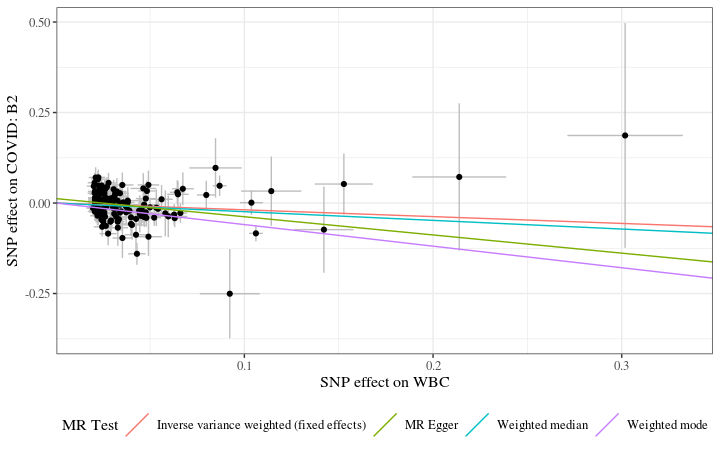

Fig. 1: Scatterplot of SNP effects for the association of the Exposure on the Outcome

## Pleiotropy

A Cochrans Q heterogeneity test can be used to formaly assesse for the presence of heterogenity (Table 7), with excessive heterogeneity indicating that there is a meaningful violation of at least one of the MR assumptions. these assumptions..

**Table 7:** Heterogenity Tests

| id.exposure | id.outcome | outcome | exposure | method | Q | Q_df | Q_pval |
| --- | --- | --- | --- | --- | --- | --- | --- |
| 5n3deM | fQWt53 | covidhgi2020anaB2v4eur23andMe | Astel2016wbc | MR Egger | 218.6923 | 162 | 0.0019960010 |
| 5n3deM | fQWt53 | covidhgi2020anaB2v4eur23andMe | Astel2016wbc | Inverse variance weighted | 225.0263 | 163 | 0.0009282652 |

Figure 2 shows a funnel plot displaying the MR estimates of individual genetic variants against their precession. Aysmmetry in the funnel plot may arrise due to some genetic variants having unusally strong effects on the outcome, which is indicative of directional pleiotropy.

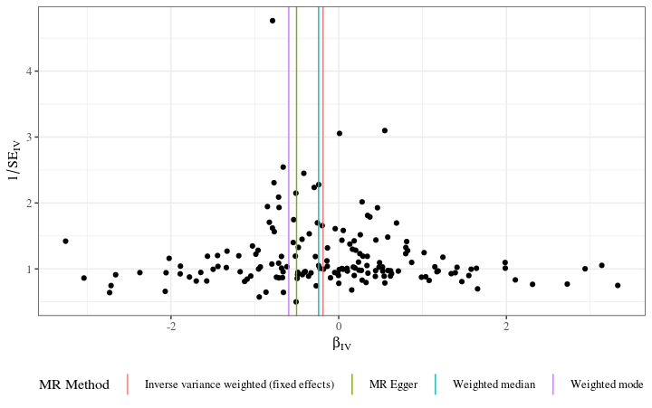

Fig. 2: Funnel plot of the MR causal estimates against their precession

Figure 3 shows a [Radial Plots](https://github.com/WSpiller/RadialMR) can be used to visualize influential data points with large contributions to Cochran’s Q Statistic that may bias causal effect estimates.

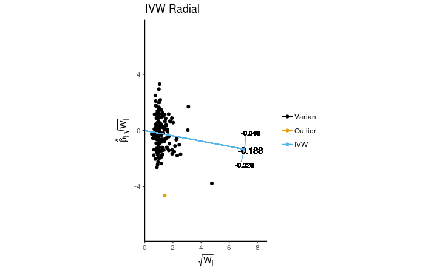

The intercept of the MR-Egger Regression model captures the average pleitropic affect across all genetic variants (Table 8).

**Table 8:** MR Egger test for directional pleitropy

| id.exposure | id.outcome | outcome | exposure | egger_intercept | se | pval |
| --- | --- | --- | --- | --- | --- | --- |
| 5n3deM | fQWt53 | covidhgi2020anaB2v4eur23andMe | Astel2016wbc | 0.01234393 | 0.005698681 | 0.03176524 |

Pleiotropy was also assesed using Mendelian Randomization Pleiotropy RESidual Sum and Outlier [(MR-PRESSO)](https://doi.org/10.1038/s41588-018-0099-7), that allows for the evlation of evaluation of horizontal pleiotropy in a standared MR model (Table 9). MR-PRESSO performs a global test for detection of horizontal pleiotropy and correction of pleiotropy via outlier removal (Table 10).

**Table 9:** MR-PRESSO Global Test for pleitropy

| id.exposure | id.outcome | outcome | exposure | pt | outliers_removed | n_outliers | RSSobs | pval |
| --- | --- | --- | --- | --- | --- | --- | --- | --- |
| 5n3deM | fQWt53 | covidhgi2020anaB2v4eur23andMe | Astel2016wbc | 5e-08 | FALSE | 1 | 229.0992 | 8e-04 |

**Table 10:** MR Estimates after MR-PRESSO outlier removal

| id.exposure | id.outcome | outcome | exposure | method | nsnp | b | se | pval |
| --- | --- | --- | --- | --- | --- | --- | --- | --- |
| 5n3deM | fQWt53 | covidhgi2020anaB2v4eur23andMe | Astel2016wbc | Inverse variance weighted (fixed effects) | 163 | -0.1651348 | 0.06068138 | 0.006501753 |
| 5n3deM | fQWt53 | covidhgi2020anaB2v4eur23andMe | Astel2016wbc | Weighted median | 163 | -0.2391381 | 0.09933822 | 0.016070439 |
| 5n3deM | fQWt53 | covidhgi2020anaB2v4eur23andMe | Astel2016wbc | Weighted mode | 163 | -0.5846455 | 0.19464399 | 0.003091265 |
| 5n3deM | fQWt53 | covidhgi2020anaB2v4eur23andMe | Astel2016wbc | MR Egger | 163 | -0.4715309 | 0.15502456 | 0.002747737 |

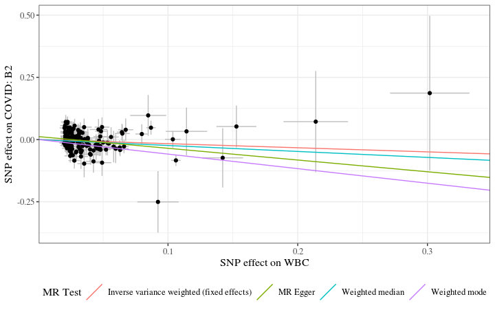

**Table 11:** Heterogenity Tests after outlier removal

| id.exposure | id.outcome | outcome | exposure | method | Q | Q_df | Q_pval |
| --- | --- | --- | --- | --- | --- | --- | --- |
| 5n3deM | fQWt53 | covidhgi2020anaB2v4eur23andMe | Astel2016wbc | MR Egger | 199.8914 | 161 | 0.02016370 |
| 5n3deM | fQWt53 | covidhgi2020anaB2v4eur23andMe | Astel2016wbc | Inverse variance weighted | 205.8806 | 162 | 0.01120587 |

**Table 12:** MR Egger test for directional pleitropy after outlier removal

| id.exposure | id.outcome | outcome | exposure | egger_intercept | se | pval |
| --- | --- | --- | --- | --- | --- | --- |
| 5n3deM | fQWt53 | covidhgi2020anaB2v4eur23andMe | Astel2016wbc | 0.01200483 | 0.005465807 | 0.02949647 |